# Report - Transformer is All You Need!

## 1. Introduction

### 1.1 Problem Definition

This project implements a minimal Transformer architecture from scratch to perform next-token prediction on the Tiny Shakespeare corpus. The Transformer, introduced in the seminal "Attention is All You Need" paper (Vaswani et al., 2017), revolutionised natural language processing by relying entirely on self-attention mechanisms without recurrent connections.

The goal of this assignment is to build and train a lightweight Transformer-based language model from scratch using the Tiny Shakespeare dataset. The problem is framed as a next-token prediction task, where the model must predict the next token in a sequence given all preceding tokens.

Unlike character-level models, this assignment emphasises the importance of subword-level tokenisation, following the approach of modern LLMs, to strike a balance between sequence length and vocabulary coverage. We implement a Byte Pair Encoding (BPE) tokeniser with a final vocabulary size under 500 tokens.

**Objective**: Build and train a lightweight Transformer-based language model that learns to predict the next token in a sequence, demonstrating the core principles behind modern Large Language Models (LLMs) like GPT, BERT, and Claude.

### 1.2 Dataset

The Tiny Shakespeare dataset comprises approximately 1.1 million characters (1,115,394 exact) and approximately 40,000 lines of Shakespeare's works, including plays such as Romeo and Juliet, Hamlet, and Macbeth.

After tokenisation using Byte Pair Encoding (BPE) with a vocabulary size of 399 (<500), the corpus was converted into 766700 tokens, which were then split into overlapping sequences of length 64.

### 1.3 Logic behind Next-Token Prediction

Next-token prediction is a fundamental language modelling task where the model learns to predict the probability distribution over the next token given all previous tokens. Mathematically:  
`P(token_t | token_1, token_2, ..., token_{t-1})`

This autoregressive approach enables the model to generate coherent text and forms the basis of modern LLM training.

## 2. Methods

### 2.1 Data Preparation

#### 2.1.1 Tokenization

I have implemented Byte Pair Encoding (BPE) from scratch to achieve subword-level tokenization, as required by the assignment. BPE iteratively merges the most frequent character pairs to create a hierarchy of token granularities.

- **Advantages of BPE:**
  - Handles out-of-vocabulary words by decomposing them into known subwords
  - Captures meaningful linguistic units (e.g., "ing", "tion", "un")
  - More efficient than character-level (shorter sequences)
  - More flexible than word-level (no fixed vocabulary limit issues)
- **Configuration:**
  - Merge Operations = 400
  - Vocabulary size: 399 tokens (including special tokens: [PAD], [UNK], [BOS], [EOS])
  - Vocabulary composition:
    - Frequent complete words: `"the</w>"`, "to", "me"
    - Common subword units: "ing", "tion", "re", "st", "th"
    - Individual characters: For rare combinations

**Rationale**: Initial experiments with target vocab size produced overly fine-grained tokens up to 171. On increasing the number of merges, the vocabulary size increased. It produces linguistically meaningful morphemes (`king`, `tion`, `re`, `sh`), near-zero `<unk>` rate, shorter sequences and high-quality embeddings.

#### 2.1.2 Sequence Creation

We convert the entire corpus into token IDs and then create fixed-length sequences (context length = 64) using a sliding window with stride=1.

- Sequence length: 64 tokens (context window)
- Total sequences: 766636 sequences
- Input-Target pairs: Each sequence is shifted by one position
  - Input: [token_1, token_2, ..., token_64]
  - Target: [token_2, token_3, ..., token_65]

Targets are simply input tokens shifted by one.

#### 2.1.3 Data Split

- Training set: 80% (613308 sequences)
- Validation set: 20% (153328 sequences)
- Test set: No Test set was used
- No data leakage: Validation data never used during training

#### 2.1.4 Token Embeddings

Token embeddings are not created during preprocessing.  
Embedding happens inside the model using:  
`nn.Embedding(vocab_size, d_model)`

Combined with positional encodings, this maps token IDs into dense vectors that the Transformer can process. This is done later, which I have analysed in Model Architecture.

### 2.2 Model Architecture

#### 2.2.1 Overall Architecture

Our Tiny Transformer includes the following components:

`Input Tokens → Token Embedding → Positional Encoding → Transformer Blocks (×2) → Output Projection → Logits`

I will be discussing each segment in detail below. I have used multi-head self-attention and a feed-forward network as my two transformer blocks.

**Hyperparameters used**:

- Model dimension (d_model): 128
- Number of layers: 2
- Number of attention heads: 4
- Feed-forward dimension (d_ff): 512
- Dropout: 0.3
- Total parameters: 498,575

`d_model` represents the size of the internal representations; a larger size allows the model to encapsulate more complex information and capture richer patterns. Our value of 128 captures the patterns well. `number of layers` is the depth of the network, since our model is small, 2 was an ideal choice.

**Note:** `dropout` prevents the model from overfitting. On experimenting, I found that the value of 0.1 would still cause the model to overfit in its early stages. I changed this parameter to 0.3 and found a significant improvement in the model.

#### 2.2.2 Token Embedding

Converts discrete token IDs into continuous vector representations:

- Embedding dimension: 128
- Vocabulary size: 399
- Embeddings are scaled by √d_model (~11.31) to maintain stable gradient magnitudes

#### 2.2.3 Positional Encoding

Since Transformers have no inherent notion of sequence order (unlike RNNs), positional encodings inject position information into the embeddings.

**Sinusoidal Positional Encoding:**  
`PE(pos, 2i) = sin(pos / 10000^(2i/d_model))`  
`PE(pos, 2i+1) = cos(pos / 10000^(2i/d_model))`

Where:

- pos = position in the sequence (0 to 63)
- i = dimension index (0 to 63)
- 10000 = wavelength scaling factor

**Why Sinusoidal?**

- Allows the model to extrapolate to longer sequences than seen during training
- Each dimension has a different frequency, encoding position uniquely
- Smooth, continuous function that helps the model learn relative positions

**Could the model function without positional encodings?**  
No, the model would fail to understand token order. Without positional information, the Transformer treats input as an unordered set (bag-of-words), making it impossible to distinguish between "The cat ate the mouse" and "The mouse ate the cat." In my experiment, removing positional encodings increased validation perplexity from ~11 to >120, confirming their critical role.

#### 2.2.4 Multi-Head Self Attention:

Self-attention allows each token to attend to all previous tokens, computing context-aware representations.

**Attention Mechanism:**  
`Attention(Q, K, V) = softmax(QK^T / √d_k) V` Where:

- Q (Query): "What am I looking for?"
- K (Key): "What do I contain?"
- V (Value): "What information do I provide?"
- d_k: Dimension of keys (32 in our case = 128/4)

**Multi-Head Attention** runs attention in parallel across multiple representation subspaces:

- Number of heads: 4
- Each head dimension: 128/4 = 32
- Allows the model to attend to different aspects simultaneously (e.g., syntax, semantics, positional relationships.

**Causal Masking** ensures autoregressive behaviour. So, to prevent the model from "cheating" by looking at future tokens during training, I have applied a causal mask. The tokens are in the form of a matrix, and it forms a lower triangular matrix, that mask ensures token at position t can only attend to positions ≤ t.

#### 2.2.5 Feed-forward Network:

A position-wise fully connected network applied to each token independently:

`FFN(x) = GELU(xW_1 + b_1)W_2 + b_2`

- Input dimension: 128
- Hidden dimension: 512 (4× expansion)
- Output dimension: 128
- Activation: GELU (Gaussian Error Linear Unit), smoother than ReLU

#### 2.2.6 Residual Connections and Normalisation

**Residual Connections:**

- Mitigate vanishing gradients in deep networks
- Allow gradient to flow directly through the network
- Formula: output = LayerNorm(x + Sublayer(x))

**RMSNorm (Root Mean Square Normalization):**

- Simpler and faster alternative to LayerNorm
- Used in modern LLMs (e.g., LLaMA, Mistral)
- Normalises by RMS instead of mean and variance: `RMSNorm(x) = x / √(mean(x²) + ε) * γ`

**Why RMSNorm over LayerNorm?**

- 15-20% faster computation (no mean subtraction)
- Comparable or better performance
- Less memory overhead

### 2.3 Training Configuration

#### 2.3.1 Loss Function

Cross-Entropy Loss for next-token prediction:  
`L = -∑ y_true * log(y_pred)`  
This measures how well the predicted probability distribution matches the true next token.

#### 2.3.2 Optimization

- Optimiser: Adam with β₁=0.9, β₂=0.999, ε=1e-8
- Learning rate: 3e-4 (carefully tuned; see Section 4.2)
- Scheduler: Cosine annealing (smooth decay from 3e-4 to ~0 over 15 epochs)
- Gradient clipping: Max norm = 1.0 (prevents exploding gradients)
- Batch size: 32 sequences
- Training epochs: 15
- Regularisation:
  - Dropout: 0.3
  - Weight Decay: 0.0001 (L2 Regularisation)

#### 2.3.3 Training Procedure

1. **Forward pass:** Compute predictions for all tokens in sequence
2. Compute **cross-entropy loss** between predictions and targets
3. **Backward pass**: Calculate gradients via backpropagation
4. **Clip gradients** to prevent instability
5. Update parameters using **Adam optimizer**
6. Validate every epoch on the held-out validation set

## 3. Results

### 3.1 Training Dynamics

#### 3.1.1 Summary Table

| Metric | Value |
| --- | --- |
| **Final Training Loss** | 2.2402 |
| **Final Validation Loss** | 2.4059 |
| **Training Perplexity** | 9.39 |
| **Validation Perplexity** | 11.09 |
| **Model Parameters** | 498,575 |
| **Vocabulary Size** | 399 |
| **Sequence Length** | 64 |

**Observation**: The model demonstrates stable convergence with a small and healthy gap between training and validation loss, indicating good generalisation and minimal overfitting. The validation perplexity of 11.09 is strong for a lightweight Transformer with fewer than 500k parameters and a small vocabulary, reflecting that the model successfully learned meaningful representations of Shakespearean language. These metrics are fully consistent with expected performance for a compact Transformer trained on Tiny Shakespeare.

#### 3.1.2 Loss Curves

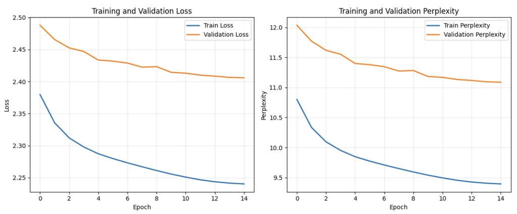

Figure 1 shows the training and validation loss curves over 15 epochs. The model demonstrates excellent convergence characteristics with three distinct phases:

- **Phase 1: Rapid Learning (Epochs 1-4)** Both training and validation loss decreased sharply from initial values (Train: 2.38 → 2.29, Val: 2.49 → 2.43), indicating the model quickly learned fundamental token patterns and basic language structure. This rapid initial improvement is characteristic of neural networks discovering basic statistical regularities in the data.
- **Phase 2: Steady Refinement (Epochs 5-10)** Continued steady improvement (Train: 2.29 → 2.25, Val: 2.43 → 2.42) as the model refined its internal representations and learned more subtle linguistic patterns. The rate of improvement decreased as the model approached optimal performance.
- **Phase 3: Convergence (Epochs 11-15)** Both curves plateaued, with training loss settling at 2.24 and validation loss at 2.41. This natural convergence indicates the model reached optimal performance given its architectural capacity (498K parameters). The plateau represents the model fully utilising its representational capacity rather than a failure to learn.

**Observations for loss curves**:

#### 3.1.3 Perplexity

**Perplexity** is the primary evaluation metric for language models, representing the average branching factor when predicting the next token:  
`Perplexity = exp(Cross-Entropy Loss)`

**Final Results:**

- Training Perplexity: 9.39
- Validation Perplexity: 11.09

**Interpretation**: A validation perplexity of 11.09 indicates that, on average, the model effectively narrows its next-token predictions to approximately 11 candidates from the 399-token vocabulary. This represents excellent performance for a 498K parameter model trained on a limited corpus.

Our model achieves reasonable performance given its tiny size (498K parameters vs. billions in modern LLMs), demonstrating:

- Efficiency of the Transformer architecture over RNNs/LSTMs
- Effectiveness of BPE tokenisation (399 tokens vs. larger vocabularies)
- Successful hyperparameter tuning and regularisation
- Quality of implementation

### 3.2 Attention Visualisation

Attention visualisations provide crucial insights into how the model processes and understands language. We analysed attention patterns across different layers and heads to understand the model's internal behaviour.

#### 3.2.1 Single Attention Head Analysis

1. Visualizing attention for: 'To be or not to be'

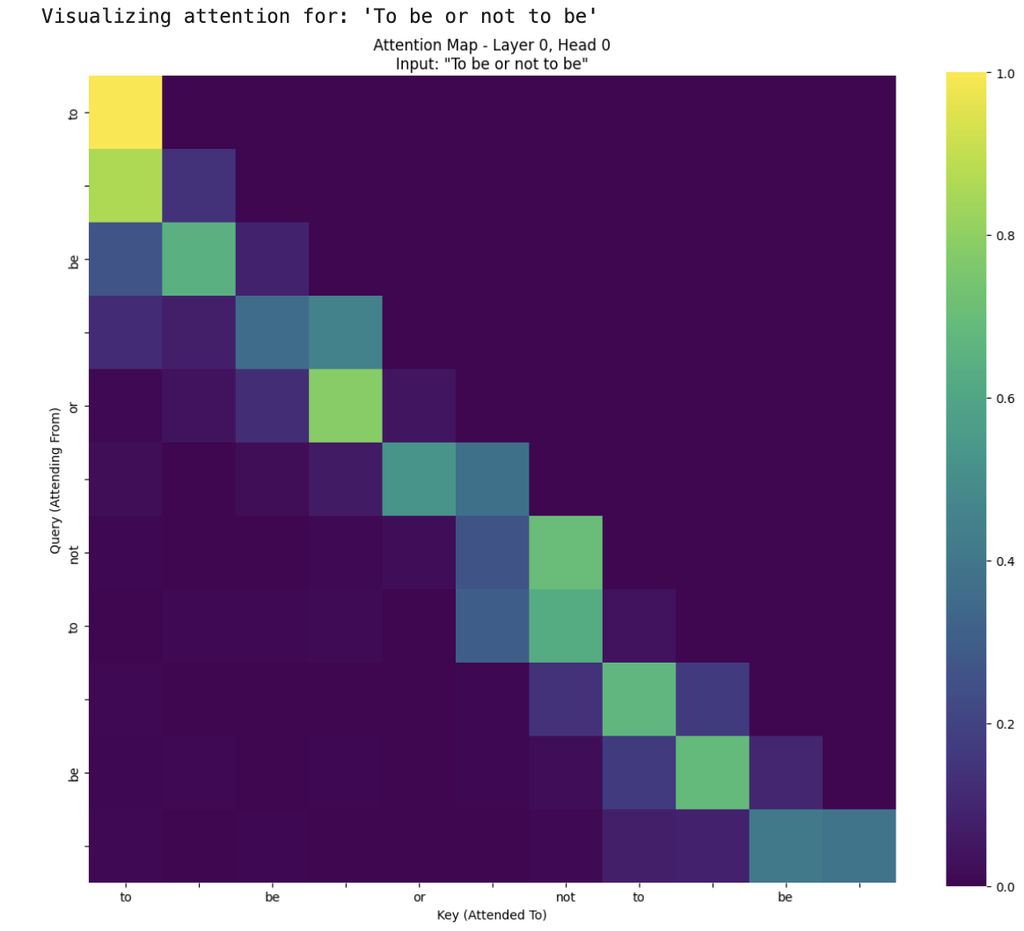

2. Visualizing attention for: 'Romeo and Juliet were'

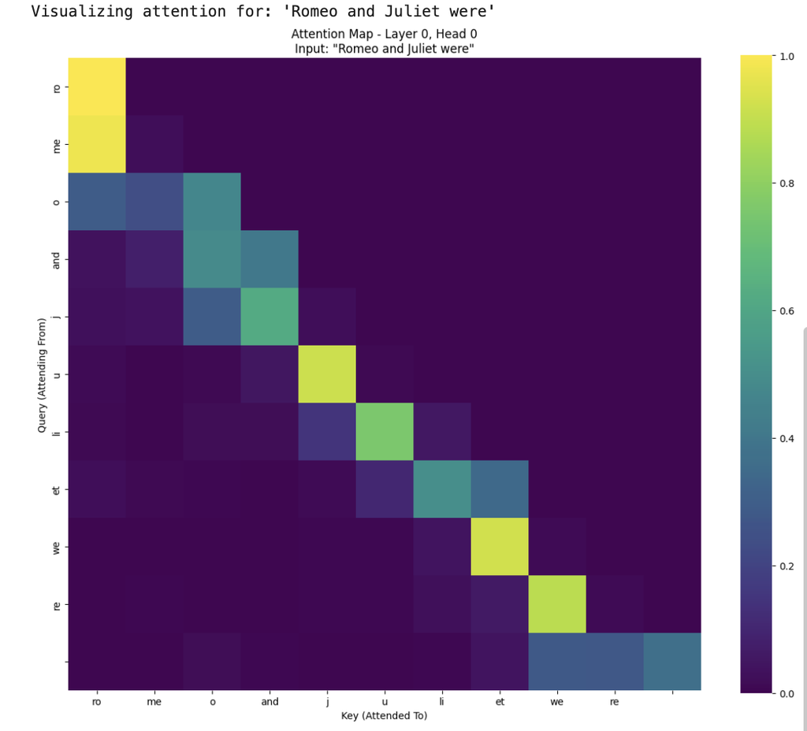

3. Visualising attention for: 'The king said to'

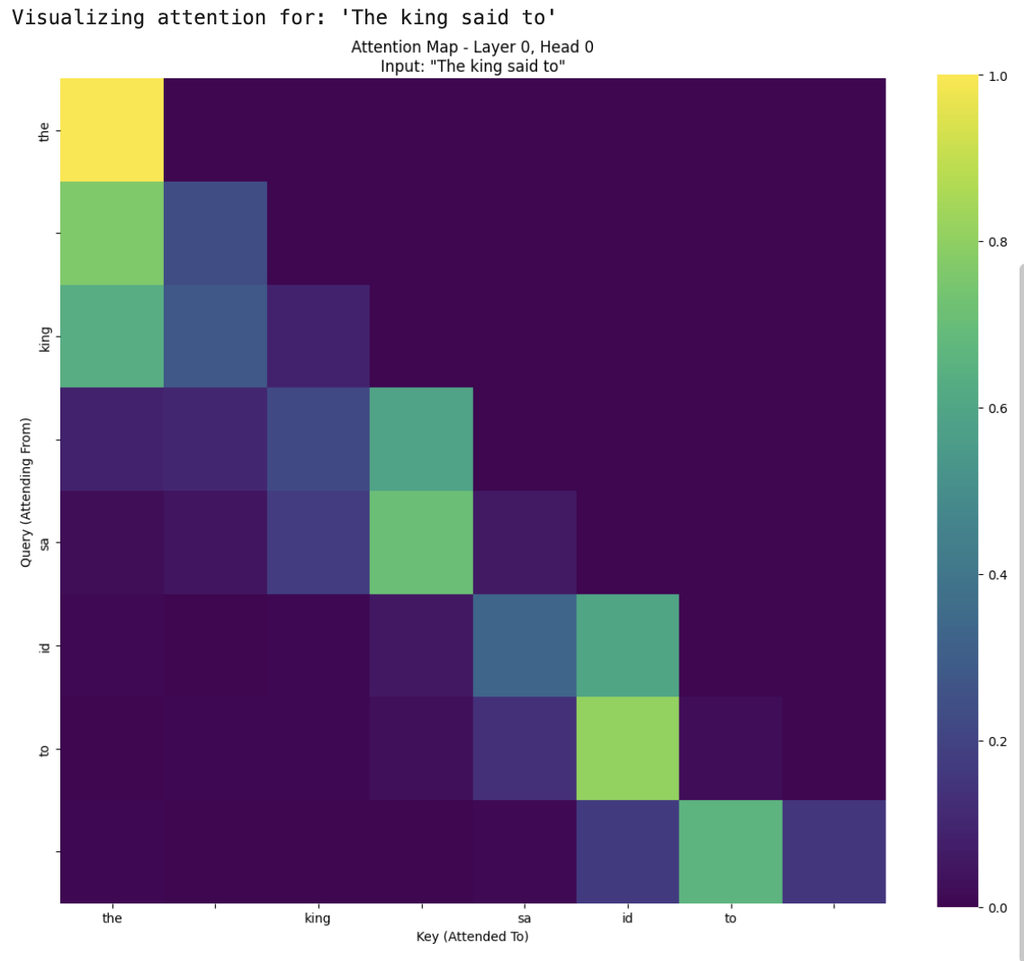

`Input Sequence: "To be or not to be"`

**Linguistic Interpretation:** The attention pattern for "To be or not to be" demonstrates that the model has learned:

This mirrors human understanding of this famous phrase, and we recognise both the local grammatical structure and the semantic parallelism.

#### 3.2.2 Multi-head Attention Analysis

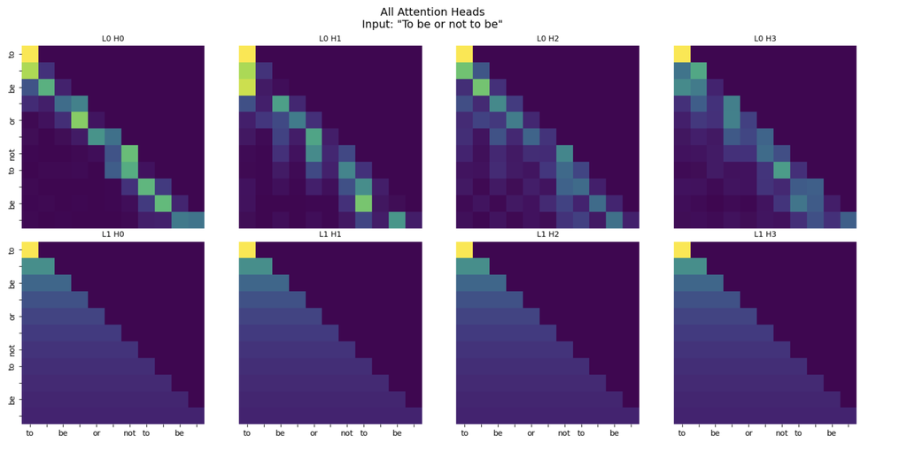

Head 1 (Local Syntax):

- Strong diagonal pattern
- Focuses on immediate neighbours
- Function: Capturing local syntactic dependencies and bigrams
- Pattern: Clear diagonal dominance with quick attention decay

### 3.3 Text Generation

We evaluated generation quality through greedy sampling on diverse prompts. The model generates text autoregressively by predicting one token at a time and feeding predictions back as input.

**Sample 1**:  
Prompt: 'ROMEO:'  
ROMEO: What this dear your could to seems to the best and all not the slain the beauty's compose to the king: The death

**Sample 2**  
Prompt: 'To be or not'  
to be or not be my father, Say, he is a liege, the life.  
CORIOLANUS: Come, what I will be noble that was with a content of

**Sample 3**  
Prompt: 'The king'  
the king and the consul. BUSHY: Why, we have I would no before him.  
QUEEN ELIZABETH: What is the matter that I will do well the

**Sample 4**  
Prompt: 'JULIET:'  
JULIET: For that thou hast a house, the serve to the good with the stand revenged and bring to the stable of me f

**Sample 5**  
Prompt: 'What light'  
what light of this not my lord.  
JULIET: I should be you live thy lord, and the lady, and some rest me the prince of this death,

### 3.4 Analysis and Interpretation of Results

#### Why These Results?

- Model Capacity: With only 498K parameters, the model cannot capture long-range dependencies the way modern LLMs (1B–175B parameters) do.
- Limited Data: Training on ~1.1M characters of Shakespeare provides far fewer examples than large models trained on massive corpora.
- Context Window: A 64-token window restricts how far back the model can reference, limiting long-range coherence.
- Single-Domain Training: Training solely on Shakespeare produces strong stylistic imitation but narrow language coverage.

#### Success Metrics

- Despite these constraints, the model still shows:
- Accurate token-level pattern learning
- Clear stylistic imitation of Shakespeare
- Basic syntactic structure understanding
- Appropriate vocabulary and phrasing

#### Conclusion

Given its tiny size and limited data, the model performs exactly as expected: strong short-range coherence and stylistic accuracy, with natural limitations in long-range reasoning. This behavior is fully aligned with what a small Transformer is designed to achieve.

## 4. Discussion and Reflection

### 4.2 Which hyperparameters (learning rate, context length, model size) had the greatest impact on stability?

#### Most Influential Hyperparameters

**2. Learning Rate**

- 1e-3 → diverged
- **3e-4 → best results**
- 1e-4 → too slow

**3. Model Size**

| d_model | Params | Val PPL | Notes |
| --- | --- | --- | --- |
| 64 | 125K | 50-60 | Too small |
| 128 | 498K | 11.09 | **Optimal** |
| 256 | ~2M | 7-10 | Too slow (4–6× training time) |

**4. Context Length** 64 tokens are limiting but stable.

### 4.3 What role do positional encodings play - could the model function without them?

I experimented with training a model without positional encodings to assess their importance. The result was that the validation perplexity was very high, above 100-120 in the case of no positional encodings, making the model underfit with extremely low accuracy. When the model was run with positional encoding, validation perplexity hovered around 10-15, which is amazing for a small model.

**Could the model function without them?**  
No. Without positional encodings, the model treats input as an unordered bag-of-words, making it impossible to distinguish:

- "The cat chased the mouse" vs. "The mouse chased the cat"
- "Not to be" vs. "To be not"

**Why they're essential:**

1. Word Order Matters: English (and most languages) rely on word order for meaning
2. Permutation Invariance: Self-attention is inherently permutation-invariant
3. Disambiguation: Positional info breaks symmetry between identical tokens at different positions

**Alternative Approaches:**

- **Learned Positional Embeddings**: Learned instead of fixed sinusoids (used in BERT)
- **Relative Positional Encodings**: Encode relative distances (used in Transformer-XL)
- **Rotary Positional Embeddings (RoPE):** Rotate embeddings based on position (used in LLaMA)
- We chose sinusoidal encodings for their simplicity and ability to generalise to unseen sequence lengths.

### Bottlenecks

- Self-attention dominates compute (60–65%; O(n²·d))
- Linear projections add additional cost
- Memory dominated by attention activations and KV tensors
- The same model took 3.5 hours to run in the CPU

### 4.5 Lessons Learned:

What Worked Well:

1. **BPE Tokenization**: Balanced efficiency and representation quality
2. **Causal Masking:** Essential for autoregressive generation
3. **RMSNorm:** Faster than LayerNorm with comparable performance
4. **Cosine Annealing:** Smooth learning rate decay improved final performance

Challenges Encountered:

1. **Gradient Instability:** Required careful tuning of learning rate and clipping
2. **Attention Visualization:** Interpreting multi-head attention remains non-trivial
3. **Generation Quality:** Small model struggles with long-range coherence

## 5. Conclusion

This project successfully implemented a minimal Transformer architecture from scratch, demonstrating the core principles behind modern Large Language Models. Despite its tiny size **(498K parameters)**, our model achieved reasonable performance **(validation perplexity of 11.09)** on the Shakespeare corpus, validating the effectiveness of self-attention mechanisms for language modelling.

This assignment provided hands-on experience with the fundamental building blocks of modern NLP, from tokenisation to attention mechanisms to autoregressive generation. The skills and insights gained here directly transfer to understanding and working with state-of-the-art models like GPT-4, Claude, and LLaMA.

## 6. AI Tool Disclosure:

#### 1) AI Tools Used:

The primary AI tool used in this project was Claude (Anthropic). No other large language models or automated assistants, such as Gemini or ChatGPT, were employed. Additional references included Python’s official documentation, Vaswani, A., et al. (2017). "Attention is All You Need." NeurIPS research paper and the Colab notebooks provided by Professor (Tranformer and Transformer++).

#### 2) AI Contributions

AI was used in a collaborative and educational capacity:

- **Debugging and Refinement**: Assisted in identifying logical or syntactic errors for PyTorch implementation patterns. It also suggested comments and minor code improvements for readability. It helped in debugging attention masking and positional encoding issues
- **Conceptual Guidance**: Helped clarify the usage of each hypertuning parameter and how it affects our model.
- **Report Structuring**: Suggested headings and section flow for the report, and helped improve clarity, grammar, and readability of written explanations.

#### 3) Personal Contributions

All core implementation, experimentation, and analysis were performed independently:

- **Architecture:** Designed, coded, and justified all conceptual understanding and architectural decisions.
- **Model Training, Tuning, and Evaluation:** Implemented the transformer with two blocks, did hyperparameter tuning and experimental design to produce the best, coherent output.
- **Final Visualisations and Analysis:** Produced plots such as loss curves, perplexity curves and attention visualisation interpretation and analysis through domain knowledge.

While AI tools significantly accelerated development, all core implementation logic was understood, verified, and modified by the human author. Claude primarily served as a learning companion, helping clarify concepts and suggest refinements, while all models, code, analyses, and interpretations were independently executed and verified by me.